# Local Weighted Regression (Loess)

Machine Learning - Section $3.2.3$

Marc Omar Haddad

Published: 16 April, 2020

**Updated: 25 April, 2020**

## Limitation of Bin Smoother Approach

A limitation of the earlier bin smoother approach (see previous notes) was that we were required to take very small windows for the approximately constant assumption to hold. This results in a small number of data points to average.

Local Weighted Regression (AKA Loess) permits us to consider larger windows and, thus, achieve more accurate, smoother trend lines.

## Mathematics of Loess

### Taylor’s Theorem

If you look close enough at any smooth function $f(x)$, the relationship will appear **linear**. The previous bin smoother approach assumed that our function is approximately constant within a window, whereas now we shall assume the function is locally linear. This permits us to use larger window sizes without sacrificing accuracy.

### Formula

For our example we will start by using a **$3$ week window**. Mathematically, our line equation for **one** window is calculated as:

$$\begin{aligned}
&E\left[Y_i\ \vert\ X_i=x_i\right] = \beta_0 + \beta_1(x_i - x_0) \\
&\mathrm{\mathbf{if}}\ \lvert{x_i-x_0}\rvert ≤ 10.5
\end{aligned}$$

We assume $Y$ given $X$ to be a line within that window (as evidenced by the linear equation).

## Plots

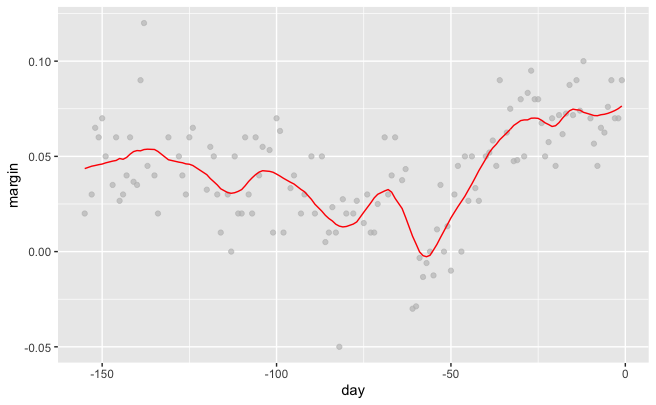

```r
total_days = diff(range(polls_2008$day))
span = 21/total_days

fit = loess(margin ~ day, degree = 1, span = span, data = polls_2008)

polls_2008 %>%
  mutate(smooth = fit$fitted) %>%
  ggplot(aes(day, margin)) +
  geom_point(alpha = 0.65, color = "grey") +
  geom_line(aes(day, smooth), color = "red")
```

Different `span` would give us different estimates.

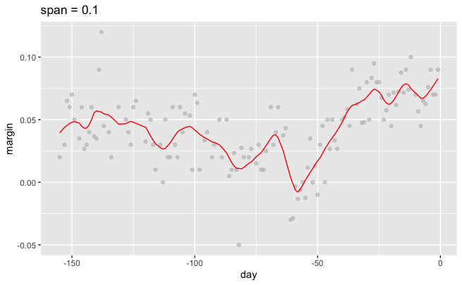

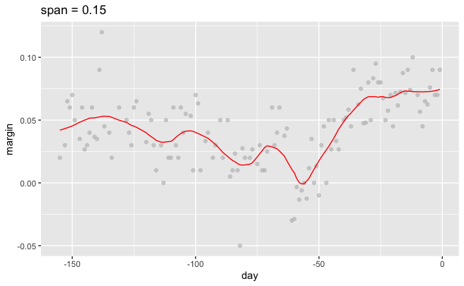

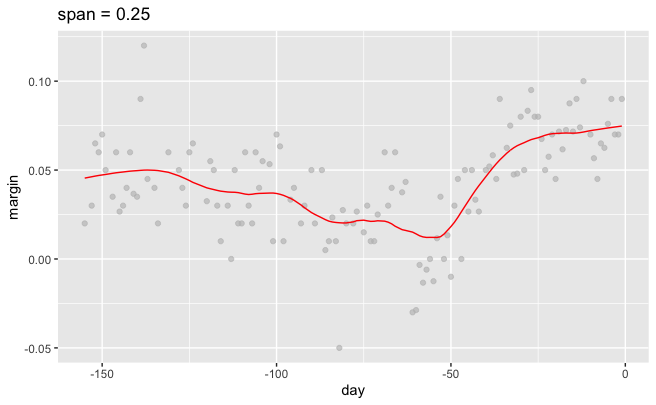

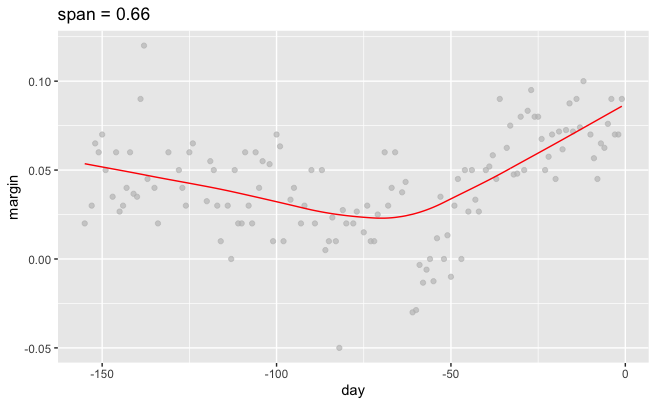

## Three Differences Between Bin Smoothing and Loess

**The First Difference:**  
Rather than keeping the bin sizes the same (regardless of number of points within bin), **Loess keeps the number of points used in the local fit the same**. The width of this window is controlled by the `span` argument, which expects a proportion. For example: if $N$ is the number of total data points, and our `span` is equal to $0.5$, **the number of data points within *any* given window will always be $0.5 \times N$ closest points to the fit**.

**The Second Difference:**  
When fitting a line locally, **Loess uses a weighted approach**. What this means is that instead of minimizing the Least Squares, **we must minimize a weighted version of Least Squares**. Represented mathematically like so:

$$\sum_{i=1}^{N}w_0(x_i)\bigl[Y_i - \left\{\beta_0 + \beta_1(x_i - x_0)\right\}\bigr]^2$$

Instead of using the Gaussian (normal) kernel for weighting, **Loess uses the Tukey Tri-Weight function**, expressed like this:

$$\begin{aligned}
&W(u) = (1 - \vert{u}\vert^3)^3&\mathrm{\mathbf{if\ }} \vert{u}\vert \le1 \\
&\mathrm{\mathbf{and}} \\
&W(u) = 0&\mathrm{\mathbf{if\ }} \vert{u}\vert > 1
\end{aligned}$$

And we use the following formula to actually define the weights:

$$w_0(x_i)=W\Bigl(\frac{x_i - x_0}{h}\Bigr)$$

**The Third Difference:**  
Loess offers the option to **fit the local model robustly**. What this means:

> “An iterative algorithm is implemented in which, after fitting a model in one iteration, **outliers** are detected and **down-weighted** for the next iteration.” - Dr. Rafael Irizarry

To use this robust option in `R`, we must set the `family` argument to `"symmetric"`.

## Important Note on Default Loess Behavior

Taylor’s Theorem also states that if you look closely at any smooth function $f(x)$, but not close enough to see a linear relationship, you will see a **parabolic relationship**. This allows for **bigger local windows** since you can capture more of the data without the function deviating from a parabolic shape. Thus, instead of a linear local model, the local model will look like this:

$$\begin{aligned}
&E\left[Y_i\ \vert\ X_i=x_i\right] = \beta_0 + \beta_1(x_i-x_0) + \beta_2(x_i - x_0)^2 \\
&\mathrm{\mathbf{if\ }} \vert{x_i - x_0}\vert \le h
\end{aligned}$$

The above is actually the default procedure when using the `loess()` function. However, in our plotted curves earlier, we set the `degree` value equal to $1$. This overrides the default behavior of looking at parabolic local modes (i.e. `degree = 2`), and instead plots according to linear local modes (i.e. `degree = 1`). We do this because **a linear local method appears to give us a smoother curve**, as seen here:

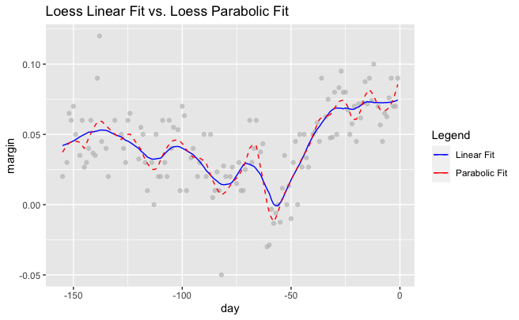

```r
fit_linear = loess(margin ~ day, degree = 1,
                   span = 0.15, data = polls_2008)
fit_parabola = loess(margin ~ day, span = 0.15, data = polls_2008)
colors = c("Linear Fit" = "blue", "Parabolic Fit" = "red")
polls_2008 %>%
  mutate(smooth_linear = fit_linear$fitted,
         smooth_parabola = fit_parabola$fitted) %>%
  ggplot(aes(x = day, y = margin)) +
  geom_point(alpha = 0.65, color = "grey") +
  geom_line(aes(day, smooth_linear, color = "Linear Fit")) +
  geom_line(aes(day, smooth_parabola, color = "Parabolic Fit"),
            linetype = "dashed") +
  labs(title = "Loess Linear Fit vs. Loess Parabolic Fit",
       color = "Legend") +
  scale_color_manual(values = colors)
```

As you can see in our above plot, the linear fit appears smoother than the parabolic fit; thus, we choose to set `degree` equal to $1$.

The `ggplot` function `geom_smooth()` uses Loess and simplifies the process of fitting a line.

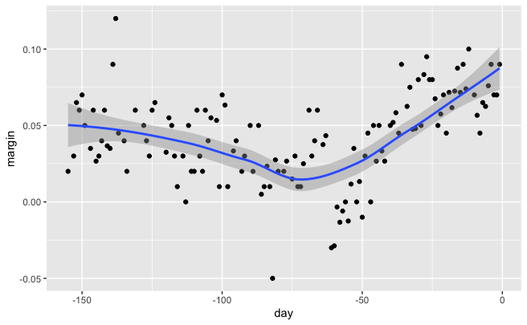

```r
polls_2008 %>%
  ggplot(aes(day, margin)) +
  geom_point() +
  geom_smooth()
```

However, the default behavior doesn’t necessarily give us the optimal fit. We can tweak the fitting process by changing the `span` and `method.args` arguments:

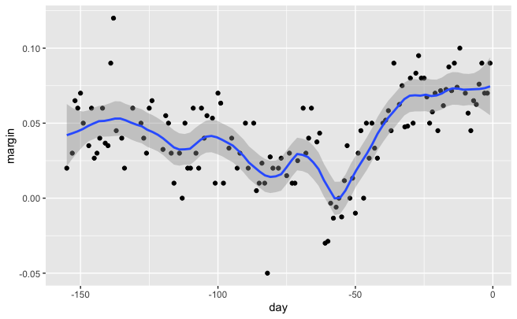

```r
polls_2008 %>%
  ggplot(aes(day, margin)) +
  geom_point() +
  geom_smooth(span = 0.15, method = "loess", method.args = list(degree = 1))
```